# P4_01_notebook_preprocessing-modelisation

## K-Nearest Neighbors

### Définition

Nous disposons d’une base de données d'apprentissage constituée de N couples « entrée-sortie ».

Pour estimer la sortie associée à une nouvelle entrée x, la méthode des k plus proches voisins **consiste à prendre en compte (de façon identique) les k échantillons d'apprentissage dont l’entrée est la plus proche de la nouvelle entrée x**, selon une distance à définir. Puisque cet algorithme est basé sur la distance, la normalisation peut améliorer sa précision.

Par exemple, dans un problème de classification, on retiendra l**a classe la plus représentée parmi les k sorties associées aux k entrées** les plus proches de la nouvelle entrée x ([source](https://fr.wikipedia.org/wiki/M%C3%A9thode_des_k_plus_proches_voisins)).

[figure not shown]

Représentations d'un KNN ([source](https://datascientest.com/knn))

### KNeighboursClassifier - GridSearch

```python
knn_model = KNeighborsClassifier()
```

```python
pipe = imbpipeline([
    ('scaler', RobustScaler()),
    ('model', knn_model)
])

params = {
            'model__n_neighbors': [2,3,4,5,6],
            'model__weights': ['uniform','distance']
}

# Création du model qui va nous permettre de comparer nos jeux de données
gs_knn = GridSearchCV(
    pipe,
    params,
    cv = 4,
    scoring = score,
    n_jobs = -1, verbose = 1)

# On entraine et on évalue le modèle
gs_knn.fit(X_train_us, y_train_us)
```

```
Fitting 4 folds for each of 10 candidates, totalling 40 fits
```

```
GridSearchCV(cv=4,
             estimator=Pipeline(steps=[('scaler', RobustScaler()),
                                       ('model', KNeighborsClassifier())]),
             n_jobs=-1,
             param_grid={'model__n_neighbors': [2, 3, 4, 5, 6],
                         'model__weights': ['uniform', 'distance']},
             scoring='roc_auc', verbose=1)
```

```python
pred_gs_knn = gs_knn.predict(X_test_us)
```

### Résultats

```python
# print classification report
get_score(y_test_us, pred_gs_knn)
```

```
              precision    recall  f1-score   support

         0.0       0.89      0.74      0.81      2186
         1.0       0.78      0.91      0.84      2186

    accuracy                           0.82      4372
   macro avg       0.83      0.82      0.82      4372
weighted avg       0.83      0.82      0.82      4372


[[1608  578]
 [ 192 1994]]
```

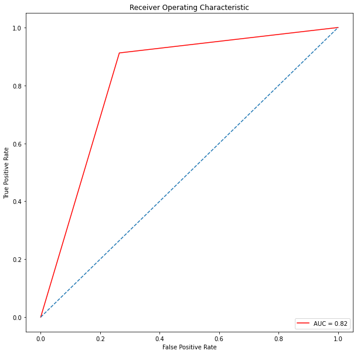

```
L'aire sous la courbe ROC :  0.8238792314730102
```

```python
draw_auroc(y_test_us, pred_gs_knn)
```

### Amélioration du modèle - entraînement sur le dataset complet avec les meilleurs hyperparamètres

```python
# On affiche les résultats
show_best(gs_knn)
```

```
Best parameters : {'model__n_neighbors': 5, 'model__weights': 'distance'}
Best score : 0.9071407822232505
```

```python
knn_tuned = KNeighborsClassifier(
            n_neighbors = gs_knn.best_params_["model__n_neighbors"],
            weights = gs_knn.best_params_["model__weights"]
)
knn_tuned.fit(X_train, y_train)
```

```
KNeighborsClassifier(weights='distance')
```

```python
pred_knn_tuned = knn_tuned.predict(X_test)
```

### Résultats

```python
# print classification report
get_score(y_test, pred_knn_tuned)
```

```
              precision    recall  f1-score   support

         0.0       0.97      0.99      0.98     28271
         1.0       0.81      0.66      0.73      2186

    accuracy                           0.96     30457
   macro avg       0.89      0.83      0.86     30457
weighted avg       0.96      0.96      0.96     30457


[[27934   337]
 [  733  1453]]
```

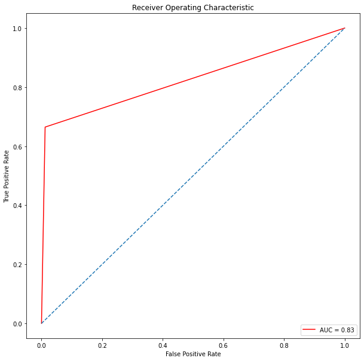

```
L'aire sous la courbe ROC :  0.8263820062929683
```

```python
draw_auroc(y_test, pred_knn_tuned)
```

## CatBoostClassifier

### Définition

`CatBoost` ou `Categorical Boosting` est une bibliothèque de boosting open source. C'est un algorithme ensembliste généralement utilisé pour résoudre des problèmes de classification.

**Les méthodes d’ensemble** sont une technique d’apprentissage automatique dans laquelle plusieurs modèles de base (apprenants faibles) sont combinés afin de produire un modèle puissant.

[figure not shown]

Représentations d'un CatBoost Classifier ([source](https://towardsdatascience.com/svm-feature-selection-and-kernels-840781cc1a6c))

### Recherche des hyperparamètres

Nous allons tester les hyperparamètres suivants :

- `iterations` : nombre d'arbres de décision.
- `model__depth` : profondeur des arbres de décision.
- `model__learning_rate` : vitesse d'apprentissage.

### CatBoost - GridSearch

```python
catboost_model = CatBoostClassifier(
    auto_class_weights="Balanced",
    verbose=False
)
```

```python
pipe = imbpipeline([
    ('model', catboost_model)
])


params =     {
        "model__iterations": [100, 500, 1000],
        "model__depth": [4, 6, 8],
        "model__learning_rate": [0.05, 0.1]
    }
catboost_gs = GridSearchCV(pipe, params, cv = 4, n_jobs = -1, verbose = 200)
```

```python
catboost_gs.fit(X_train_us, y_train_us)
```

```
Fitting 4 folds for each of 18 candidates, totalling 72 fits
```

```
GridSearchCV(cv=4,
             estimator=Pipeline(steps=[('model',
                                        <catboost.core.CatBoostClassifier object at 0x7f7325b6b1c0>)]),
             n_jobs=-1,
             param_grid={'model__depth': [4, 6, 8],
                         'model__iterations': [100, 500, 1000],
                         'model__learning_rate': [0.05, 0.1]},
             verbose=200)
```

```python
pred_catboost = catboost_gs.predict(X_test_us)
```

### Résultats

```python
get_score(y_test_us, pred_catboost)
```

```
              precision    recall  f1-score   support

         0.0       0.96      0.96      0.96      2186
         1.0       0.96      0.96      0.96      2186

    accuracy                           0.96      4372
   macro avg       0.96      0.96      0.96      4372
weighted avg       0.96      0.96      0.96      4372


[[2108   78]
 [  80 2106]]
```

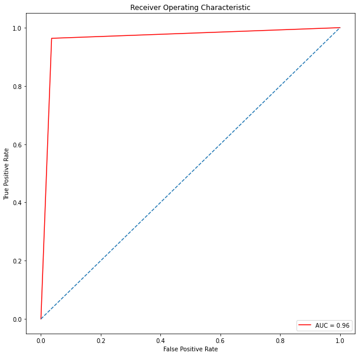

```
L'aire sous la courbe ROC :  0.9638609332113449
```

```python
draw_auroc(y_test_us, pred_catboost)
```

### Amélioration du modèle - entraînement sur le dataset complet avec les meilleurs hyperparamètres

```python
show_best(catboost_gs)
```

```
Best parameters : {'model__depth': 8, 'model__iterations': 1000, 'model__learning_rate': 0.1}
Best score : 0.9485218728639782
```

```python
catboost_tuned = CatBoostClassifier(
                     learning_rate = catboost_gs.best_params_["model__learning_rate"],
                      max_depth = catboost_gs.best_params_["model__depth"],
                      iterations = catboost_gs.best_params_["model__iterations"]
                    )
catboost_tuned.fit(X_train, y_train)
```

```
0:	learn: 0.5710327	total: 30.6ms	remaining: 30.6s
1:	learn: 0.4889203	total: 72.8ms	remaining: 36.3s
2:	learn: 0.4222756	total: 103ms	remaining: 34.3s
3:	learn: 0.3723038	total: 133ms	remaining: 33.2s
4:	learn: 0.3347897	total: 162ms	remaining: 32.2s
5:	learn: 0.3059578	total: 191ms	remaining: 31.6s
6:	learn: 0.2876783	total: 204ms	remaining: 28.9s
7:	learn: 0.2713575	total: 232ms	remaining: 28.8s
8:	learn: 0.2575926	total: 271ms	remaining: 29.8s
9:	learn: 0.2473561	total: 308ms	remaining: 30.5s
10:	learn: 0.2368081	total: 345ms	remaining: 31.1s
11:	learn: 0.2289387	total: 374ms	remaining: 30.8s
12:	learn: 0.2208124	total: 405ms	remaining: 30.7s
13:	learn: 0.2158185	total: 437ms	remaining: 30.7s
14:	learn: 0.2123275	total: 474ms	remaining: 31.1s
15:	learn: 0.2081811	total: 506ms	remaining: 31.1s
16:	learn: 0.2042958	total: 547ms	remaining: 31.6s
17:	learn: 0.2000420	total: 580ms	remaining: 31.6s
18:	learn: 0.1959211	total: 610ms	remaining: 31.5s
19:	learn: 0.1936363	total: 641ms	remaining: 31.4s
20:	learn: 0.1917170	total: 680ms	remaining: 31.7s
21:	learn: 0.1893585	total: 711ms	remaining: 31.6s
22:	learn: 0.1874968	total: 740ms	remaining: 31.4s
23:	learn: 0.1848796	total: 782ms	remaining: 31.8s
24:	learn: 0.1835639	total: 813ms	remaining: 31.7s
25:	learn: 0.1817354	total: 849ms	remaining: 31.8s
26:	learn: 0.1800599	total: 892ms	remaining: 32.1s
27:	learn: 0.1781150	total: 924ms	remaining: 32.1s
28:	learn: 0.1762204	total: 954ms	remaining: 31.9s
29:	learn: 0.1746062	total: 984ms	remaining: 31.8s
30:	learn: 0.1734227	total: 1.02s	remaining: 32s
31:	learn: 0.1721011	total: 1.06s	remaining: 32s
32:	learn: 0.1704655	total: 1.1s	remaining: 32.3s
33:	learn: 0.1689815	total: 1.13s	remaining: 32.2s
34:	learn: 0.1674411	total: 1.16s	remaining: 32.1s
35:	learn: 0.1660521	total: 1.2s	remaining: 32.1s
36:	learn: 0.1647723	total: 1.23s	remaining: 32.1s
37:	learn: 0.1639794	total: 1.27s	remaining: 32.1s
38:	learn: 0.1628871	total: 1.31s	remaining: 32.2s
39:	learn: 0.1618449	total: 1.34s	remaining: 32.2s
```

[output cut: 945 more lines]

```
985:	learn: 0.0170055	total: 32s	remaining: 455ms
986:	learn: 0.0169625	total: 32.1s	remaining: 422ms
987:	learn: 0.0169445	total: 32.1s	remaining: 390ms
988:	learn: 0.0169240	total: 32.1s	remaining: 357ms
989:	learn: 0.0168808	total: 32.2s	remaining: 325ms
990:	learn: 0.0168666	total: 32.2s	remaining: 292ms
991:	learn: 0.0168376	total: 32.2s	remaining: 260ms
992:	learn: 0.0168184	total: 32.3s	remaining: 227ms
993:	learn: 0.0167981	total: 32.3s	remaining: 195ms
994:	learn: 0.0167743	total: 32.3s	remaining: 162ms
995:	learn: 0.0167570	total: 32.4s	remaining: 130ms
996:	learn: 0.0167434	total: 32.4s	remaining: 97.4ms
997:	learn: 0.0167289	total: 32.4s	remaining: 65ms
998:	learn: 0.0167117	total: 32.4s	remaining: 32.5ms
999:	learn: 0.0166810	total: 32.5s	remaining: 0us
```

```
<catboost.core.CatBoostClassifier at 0x7f7325f1cf10>
```

```python
pred_cb_tuned = catboost_tuned.predict(X_test)
```

### Résultats

```python
get_score(y_test, pred_cb_tuned)
```

```
              precision    recall  f1-score   support

         0.0       0.99      1.00      0.99     28271
         1.0       1.00      0.87      0.93      2186

    accuracy                           0.99     30457
   macro avg       0.99      0.93      0.96     30457
weighted avg       0.99      0.99      0.99     30457


[[28263     8]
 [  287  1899]]
```

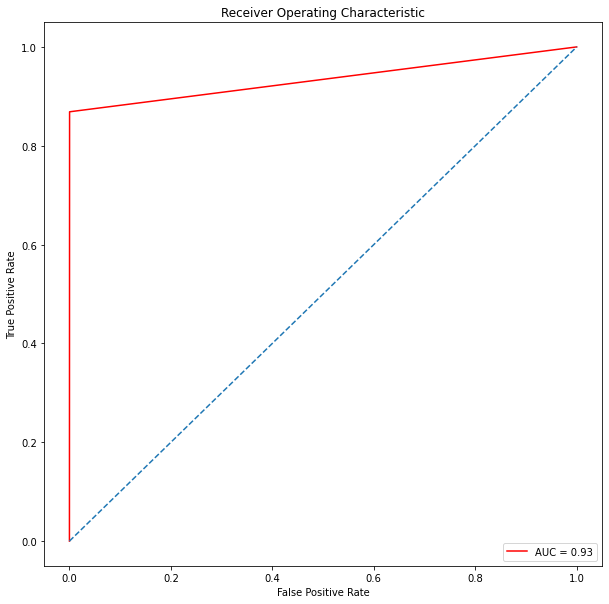

```
L'aire sous la courbe ROC :  0.9342134985326795
```

```python
draw_auroc(y_test, pred_cb_tuned)
```

## Light Gradient Boosted Machine

### Définition

LGBM est un framework de levage de gradient rapide, distribué et hautes performances basé sur un algorithme d’apprentissage automatique populaire – Decision Tree. Cet algorithme **grandit par feuille et choisit la valeur delta maximale à grandir.** LightGBM utilise des algorithmes basés sur des histogrammes. Les avantages de ceci sont les suivants :

- Moins d’utilisation de la mémoire
- Réduction des coûts de communication pour l’apprentissage parallèle
- Réduction des coûts pour le calcul du gain pour chaque division dans l’arbre de décision.

Ainsi, comme LightGBM s’entraîne beaucoup plus rapidement, cela peut parfois entraîner un surapprentissage. Voyons donc quels paramètres peuvent être ajustés pour obtenir un meilleur modèle optimal.

[figure not shown]

Représentations d'un Light GBM Classifier ([source](https://towardsdatascience.com/svm-feature-selection-and-kernels-840781cc1a6c))

### Recherche des hyperparamètres

Pour obtenir une meilleure précision, les paramètres suivants doivent être réglés :

- Plus de données d’entraînement ajoutées au modèle peuvent augmenter la précision.
- `num_leaves` : augmenter sa valeur augmentera la précision car le fractionnement se fait par feuille, mais un surajustement peut également se produire.
- `max_bin` : une valeur élevée aura un impact majeur sur la précision mais finira par entraîner un surapprentissage.

```python
lgbm_model = LGBMClassifier()
```

```python
pipe = imbpipeline([
    ('scaler', RobustScaler()),
    ('model', lgbm_model)
])


params = {
    'model__max_bin': [32, 63],
    'model__num_leaves': [20,31]
}

lgbm_gs = GridSearchCV(pipe, params, cv = 4, n_jobs = -1, verbose = 200)
```

```python
lgbm_gs.fit(X_train_us, y_train_us)
```

```
Fitting 4 folds for each of 4 candidates, totalling 16 fits
```

```
GridSearchCV(cv=4,
             estimator=Pipeline(steps=[('scaler', RobustScaler()),
                                       ('model', LGBMClassifier())]),
             n_jobs=-1,
             param_grid={'model__max_bin': [32, 63],
                         'model__num_leaves': [20, 31]},
             verbose=200)
```

```python
pred_lgbm = lgbm_gs.predict(X_test_us)
```

### Résultats

```python
get_score(y_test_us, pred_lgbm)
```

```
              precision    recall  f1-score   support

         0.0       0.85      0.92      0.88      2186
         1.0       0.91      0.83      0.87      2186

    accuracy                           0.88      4372
   macro avg       0.88      0.88      0.88      4372
weighted avg       0.88      0.88      0.88      4372


[[2010  176]
 [ 365 1821]]
```

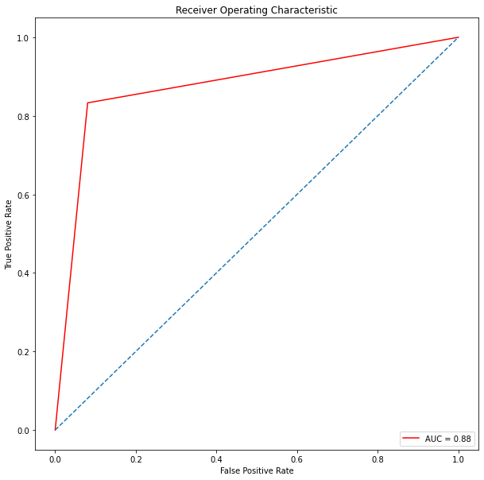

```
L'aire sous la courbe ROC :  0.8762580054894786
```

```python
draw_auroc(y_test_us, pred_lgbm)
```

### Amélioration du modèle - entraînement sur le dataset complet avec les meilleurs hyperparamètres

```python
import re
X_train = X_train.rename(columns = lambda x:re.sub('[^A-Za-z0-9_]+', '', x))
X_test = X_test.rename(columns = lambda x:re.sub('[^A-Za-z0-9_]+', '', x))
```

```python
show_best(lgbm_gs)
```

```
Best parameters : {'model__max_bin': 63, 'model__num_leaves': 31}
Best score : 0.88869543559683
```

```python
lgbm_tuned = LGBMClassifier(max_bin = lgbm_gs.best_params_["model__max_bin"],
                           num_leaves = lgbm_gs.best_params_["model__num_leaves"]
                           )
lgbm_tuned.fit(X_train, y_train)
```

```
LGBMClassifier(max_bin=63)
```

```python
pred_lgbm_tuned = lgbm_tuned.predict(X_test)
```

### Résultats

```python
get_score(y_test, pred_lgbm_tuned)
```

```
              precision    recall  f1-score   support

         0.0       0.95      1.00      0.97     28271
         1.0       0.97      0.33      0.49      2186

    accuracy                           0.95     30457
   macro avg       0.96      0.66      0.73     30457
weighted avg       0.95      0.95      0.94     30457


[[28249    22]
 [ 1471   715]]
```

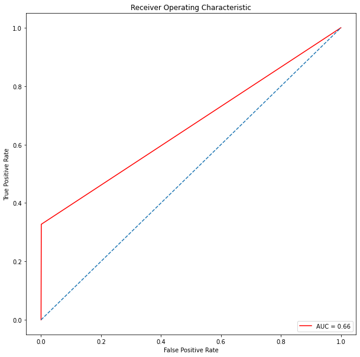

```
L'aire sous la courbe ROC :  0.6631516223372383
```

```python
draw_auroc(y_test, pred_lgbm_tuned)
```

## Le meilleur score

```python
rf = [0.77,0.86,0.82,0.821]
lr = [0.68,0.70,0.70,0.695]
svm = [0.69,0.70,0.70,0.698]
knn = [0.91,0.78,0.82,0.823]
cb = [0.96,0.96,0.96,0.96]
lgbm = [0.83,0.91,0.88,0.876]


rf_tuned = [0.08,1.0,0.93,0.538]
lr_tuned = [0.0,0.0,0.93,0.5]
svm_tuned = [0.0,0.0,0.93,0.5]
knn_tuned = [0.66,0.81,0.96,0.826]
cb_tuned = [0.87,1.0,0.99,0.934]
lgbm_tuned = [0.33,0.97,0.95,0.663]

score_test = {
    'Random Forest':(rf),'Logistic Regression':(lr),
    'SVM':(svm),'KNN':(knn),'CatBoost':(cb),'LGBM':(lgbm),
    'RandomForest Tuned':(rf_tuned),
    'Logistic Regression Tuned':(lr_tuned),
    'SVM Tuned':(svm_tuned),
    'KNN Tuned':(knn_tuned),
    'CatBoost Tuned':(cb_tuned),
    'LGBM Tuned':(lgbm_tuned)
}


test_df = pd.DataFrame(score_test)
test_df.index= ['Recall TP','Precision FP','Accuracy','AUROC']
test_df.T
```

|  | Recall TP | Precision FP | Accuracy | AUROC |
| --- | --- | --- | --- | --- |
| Random Forest | 0.77 | 0.86 | 0.82 | 0.821 |
| Logistic Regression | 0.68 | 0.70 | 0.70 | 0.695 |
| SVM | 0.69 | 0.70 | 0.70 | 0.698 |
| KNN | 0.91 | 0.78 | 0.82 | 0.823 |
| CatBoost | 0.96 | 0.96 | 0.96 | 0.960 |
| LGBM | 0.83 | 0.91 | 0.88 | 0.876 |
| RandomForest Tuned | 0.08 | 1.00 | 0.93 | 0.538 |
| Logistic Regression Tuned | 0.00 | 0.00 | 0.93 | 0.500 |
| SVM Tuned | 0.00 | 0.00 | 0.93 | 0.500 |
| KNN Tuned | 0.66 | 0.81 | 0.96 | 0.826 |
| CatBoost Tuned | 0.87 | 1.00 | 0.99 | 0.934 |
| LGBM Tuned | 0.33 | 0.97 | 0.95 | 0.663 |

- `Best parameters` : {'model**depth': 8, 'model**iterations': 1000, 'model__learning_rate': 0.1}
- `Best score` : 0.9485218728639782

# 5. Interprétabilité du modèle

## Coût métier

L'objectif étant de donner une vision globale aux chargés de clientèle pour la prise de décision, essayons de définir une fonction coût métier.

**Hypothèse**

Il est important de prendre un peu de recul afin d'analyser les données d'un point de vue client. L'objectif est de minimiser une perte d'argent par la banque suite à une mauvaise décision. Deux conséquences sont envisageables :

- une **perte dla marge** quand un bon client est considéré comme mauvais (crédit non accordé à tort) (FP)
- une **perte sur le capital non remboursé** quand on décide d'accorder un prêt à un mauvais client (crédit à accordé à tort) (FN et TP)

Quel poids accorder aux erreurs de décision ? Logiquement, un FP n’a pas le même coût qu’un FN/TP, il est plus coûteux de perdre le capital qu'une marge.

## SHAP

Afin de présenter les résultats aux conseillers de banque, nous devons être en mesure d'expliquer l’importance des variables qui ont poussé le modèle à attribuer à un client une probabilité de remboursement ou non. Pour cela, nous allons nous servir de `l'outil SHAP`.

La méthode `SHapley Additive exPlanations` va permettre d'évaluer l'influence que chaque variable a eu dans le résultat de la prédiction. Nous pourrons donc facilement interpréter chaque prédiction en observant les variables qui ont le plus influencé le résultat.

[figure not shown]

SHAP

Voici les approches que nous allons réaliser avec SHAP :

- Impact de variables - importance globale
- Impact de variables - importance locale
- Impact de variables - importance multiclass

### Impact de variables - importance globale

Dans ce chapitre nous allons obtenir un aperçu des variables les plus importantes pour un modèle.

Pour ce faire, nous pouvons tracer les valeurs SHAP de chaque variable pour chaque échantillon. Le graphique ci-dessous représente **l’importance globale des variables** calculées par les valeurs de Shap. Grâce au fait que les valeurs sont calculées pour chaque exemple du dataset, il est possible de représenter chaque exemple par un point et ainsi avoir une information supplémentaire sur **l’impact de la variable en fonction de sa valeur.**

Les valeurs de Shap sont représentées pour chaque variable dans leur ordre d’importance, chaque point représente une valeur de Shap (pour un exemple) :

- les points rouges représentent des valeurs élevées de la variable
- les points bleus représentent des valeurs basses de la variable

```python
import catboost
from catboost import *
shap.initjs()
```

```python
my_model = CatBoostClassifier(iterations=300, learning_rate=0.1, random_seed=12).fit(X_train, y_train, verbose=False, plot=False)
```

```python
explainer = shap.TreeExplainer(my_model)
shap_values = explainer.shap_values(Pool(X_train, y_train))
```

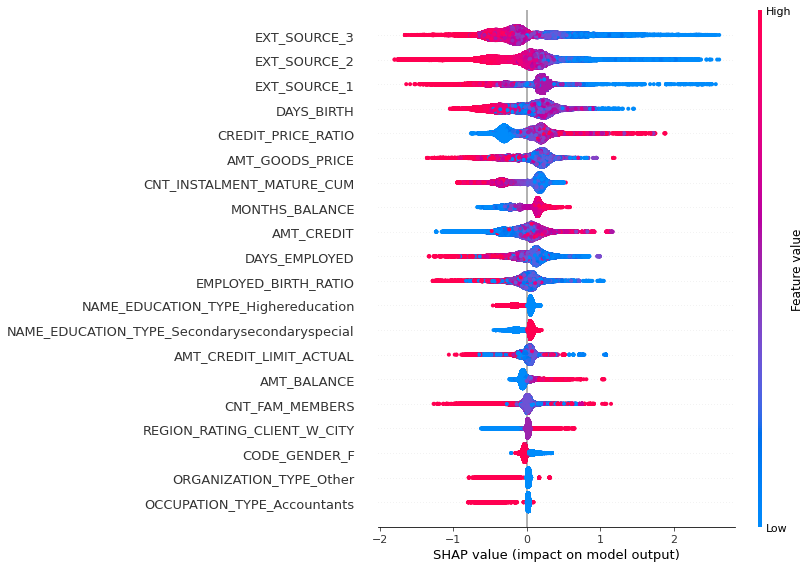

```python
shap.summary_plot(shap_values, X_train)
```

**Remarques**

- `EXT_SOURCE_3`, `EXT_SOURCE_2`,`EXT_SOURCE_1` : Notes externes du client
- `DAYS_BIRTH` : Age du client
- `CREDIT_PRICE_RATIO` : Rapport entre le montant emprunté et le prix du bien acheté
- `AMT_GOODS_PRICE` : Montant du prix du bien
- `CNT_INSTALMENT_MATURE_CUM` : Nombre d'échéances payées sur le crédit précédent

Nous remarquons que deux parmi les features affichées ont été ajoutées lors du feature engineering :

- `EMPLOYED_BIRTH_RATIO`
- `CREDIT_PRICE_RATIO`

Cela révèle par exemple que les notes externes du client (`EXT_SOURCE_X`) ont un impact positif quand leurs valeurs sont basses. Quant à la feature `CREDIT_PRICE_RATIO`, son impact est négatif quand sa valeur est basse.

### Impact de variables - importance locale

Nous examinerons ici les valeurs SHAP attribuées à deux observations :

- un client solvable
- un client non solvable

```python
test_objects = [X_train.iloc[7:8], X_train.iloc[81:82]]

for obj in test_objects:
    print('Probabilité de TARGET == 1 : {:.4f}'.format(my_model.predict_proba(obj)[0][1]))
    print('Prédiction brute : {:.4f}'.format(my_model.predict(obj, prediction_type='RawFormulaVal')[0]))
    print('\n')
```

```
Probabilité de TARGET == 1 : 0.0104
Prédiction brute : -4.5536


Probabilité de TARGET == 1 : 0.8613
Prédiction brute : 1.8262
```

Nous allons visualiser les données brutes sous forme de graphique. Le graphique montrera les features contribuant chacune à la prédiction finale pour un client donné :

- en rouge, les variables qui ont un **impact positif** (contribuent à ce que la prédiction soit plus élevée que la valeur de base)
- en bleu, celles ayant un **impact négatif** (contribuent à ce que la prédiction soit plus basse que la valeur de base)

**Client solvable**

```python
shap.force_plot(explainer.expected_value, shap_values[7,:], X_train.iloc[7,:])
```

Le client figurant dans la ligne 7 représente une probabilité de 0.99% de rembourser le crédit dans les délais. Nous observons les contributions de variables suivantes :

- positive des variables `EXT_SOURCE_1`, `CNT_INSTALMENT_MATURE_CUM`
- négative des variables `EXT_SOURCE_3`, `EMPLOYED_BIRTH_RATIO` et `DAYS_EMPLOYED`

**Client non-solvable**

```python
shap.force_plot(explainer.expected_value, shap_values[81,:], X_train.iloc[81,:])
```

Le client figurant dans la ligne 81 représente une probabilité de 0.86% de faire défaut. Nous observons les contributions de variables suivantes :

- positive des variables `EXT_SOURCE_2`, `EXT_SOURCE_3`, `DAYS_BIRTH` et `NAME_HOUSING_TYPE_Houseapartment`
- négative des variables `MONTHS_BALANCE`

**Remarque**

La valeur de base du dataset est à `-3.594`. La prédiction de la valeur médiane de la probabilité de remboursement dans l’exemple 1 est de `-4.55` et de `+1.83` dans le deuxième. Nous étudions donc deux exemples de classification qui se positionnent des deux côtés de la moyenne, nous voyons cependant que les raisons du modèle pour lesquelles les valeurs sont scorées de cette façon sont différentes (contribution positive de `EXT_SOURCE_1` pour le premier et contribution positive de `EXT_SOURCE_2` et `EXT_SOURCE_3` pour le deuxième).

### Impact de variables - importance multiclass

Il est également possible d'analyser l'impact de features d'un point de vue multicatégoriel. Ci-dessous nous allons visualiser :

- un récapitulatif des valeurs SHAP pour les prédictions brutes pour la classe 0
- un récapitulatif des valeurs SHAP pour les prédictions brutes pour la classe 1

```python
model = CatBoostClassifier(loss_function = 'MultiClass', iterations=300, learning_rate=0.1, random_seed=123)
model.fit(X_train, y_train, verbose=False, plot=False)
```

```
<catboost.core.CatBoostClassifier at 0x7f7325880640>
```

```python
explainer = shap.TreeExplainer(model)
shap_values = explainer.shap_values(Pool(X_train, y_train))
```

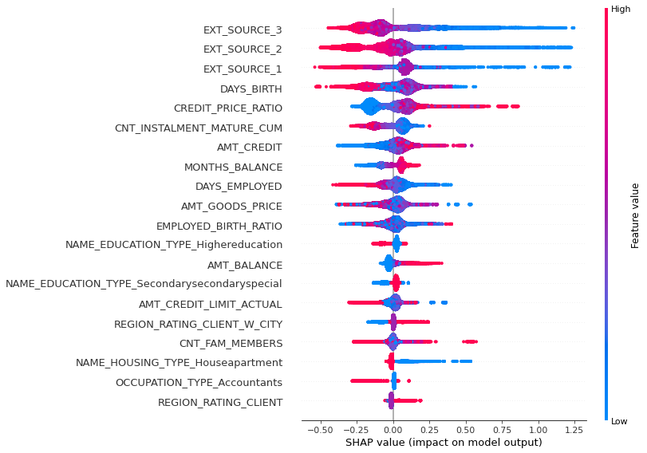

```python
shap.summary_plot(shap_values[1], X_train)
```

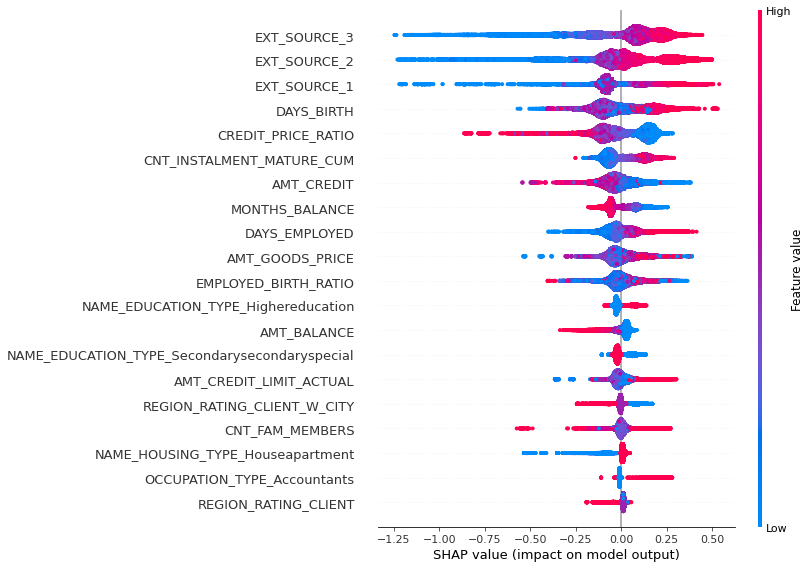

```python
shap.summary_plot(shap_values[0], X_train)
```

Les variables qui impactent le plus les deux classes `0` et `1` sont les mêmes.

**Conclusions**

Grâce à SHAP nous pouvons comprendre aisément les contributions de features dans la génération de la prédiction finale. Les différents plots affichent clairement les caractéristiques qui ont contribué positivement ou négativement à la valeur de base pour générer une prédiction.

En d'autres termes, SHAP permet d'expliquer pourquoi une prédiction à été différente par rapport à la baseline.

Ceci est une information-clé pour les conseillers de la banque. En cas de refus, ils vont pouvoir s'appuyer sur les informations fournies par SHAP :

- les notes externes d'un demandeur de crédit sont favorables ou défavorables ?
- l'âge du demandeur de crédit est-il favorable ?
- le rapport entre le montant emprunté et le prix du bien acheté joue-t-il en faveur du client ?

Il ne faut pas oublier l'aspect légal : **l’article 22 du RGPD prévoit des règles** pour éviter que l’homme ne subisse des décisions émanant uniquement de machines. Les modèles sans explication risquent d’entraîner une sanction qui peut s’élever à 20 000 000 d’euros ou, dans le cas d’une entreprise, à 4% du chiffre d’affaires mondial total de l’exercice précédent (le montant le plus élevé étant retenu) [source](https://www.aquiladata.fr/insights/shap-mieux-comprendre-linterpretation-de-modeles/)